# Association of nutrition trajectory and outcomes in pediatric leukemia and lymphoma patients

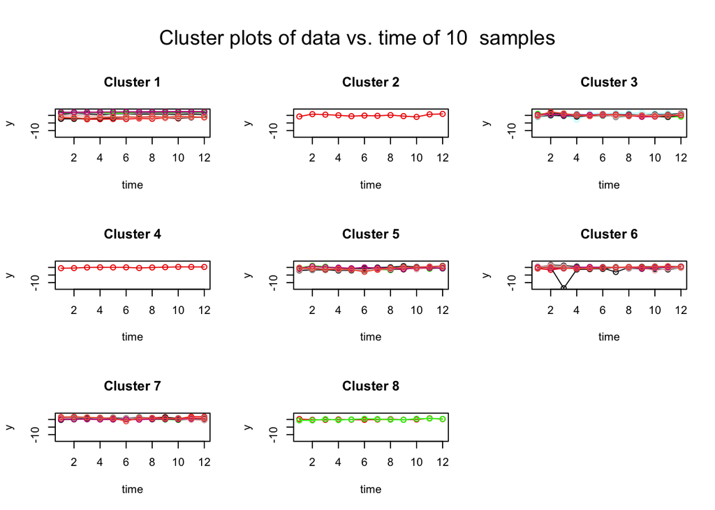

```r
plot(s3.8clusters)
```

For both the 4 and 8 cluster solutions, boxplots of the trajectories were obtained. In the 4 cluster solution, the boxplots centered around 0 with cluster 3 having the most variability.

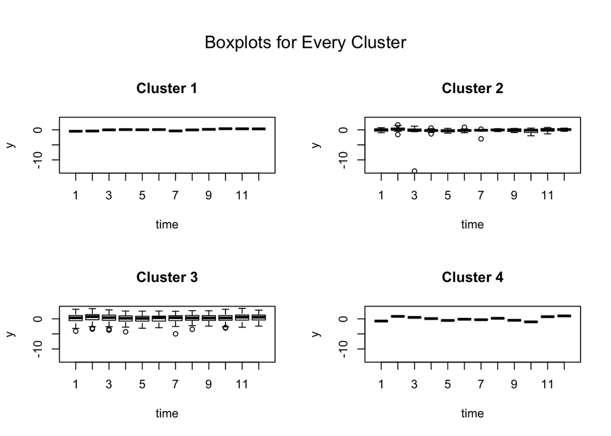

```r
# Plot boxplots
plotBoxplotTraj(s3.4clusters)
```

In the 8 cluster solution, the majority of the clusters again were close to 0. The exceptions were cluster 5 which was below 0 near a typical z-score of -1 and cluster 7 had a z-score consistently above 0 and near 1.

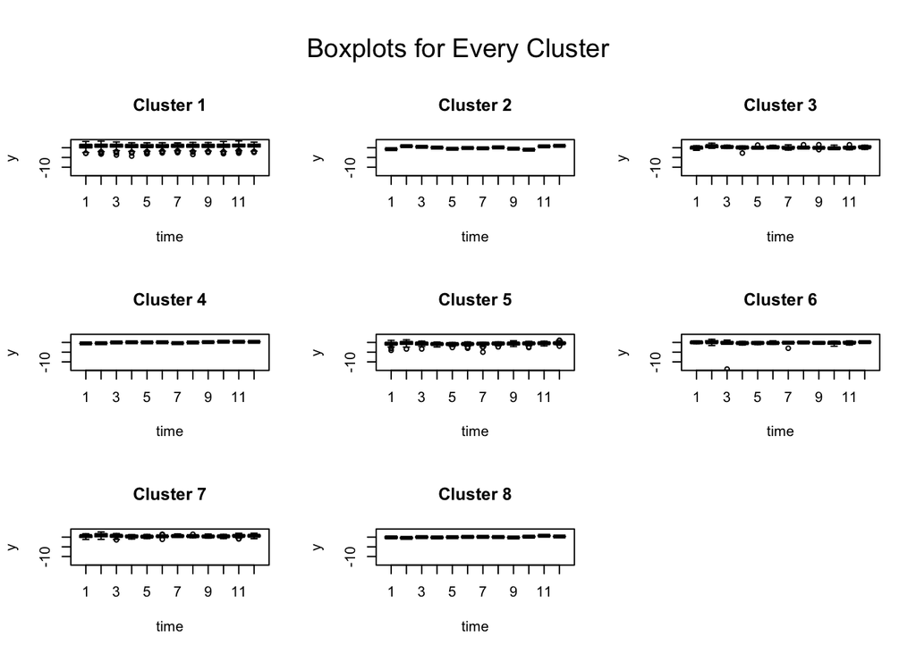

```r
plotBoxplotTraj(s3.8clusters)
```

After examing the boxplots, the 4 cluster solution was expected to have mean cluster z-scores near 0. The mean z-scores for the trajectories were graphed and the result of the 4 cluster solution is shown.

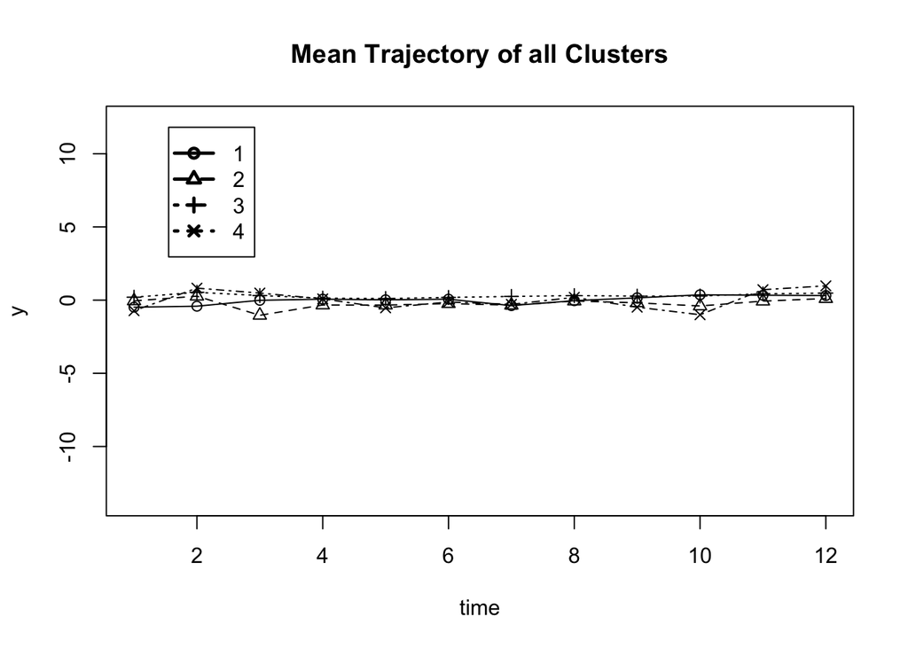

```r
# Plot mean combination trajectories
plotCombTraj(s3.4clusters)
```

Likewise, the 8 cluster solution was also graphed with the mean z-scores plotted. As expected, cluster 5 was the cluster with the lowest mean z-score and this was consistently near -1.

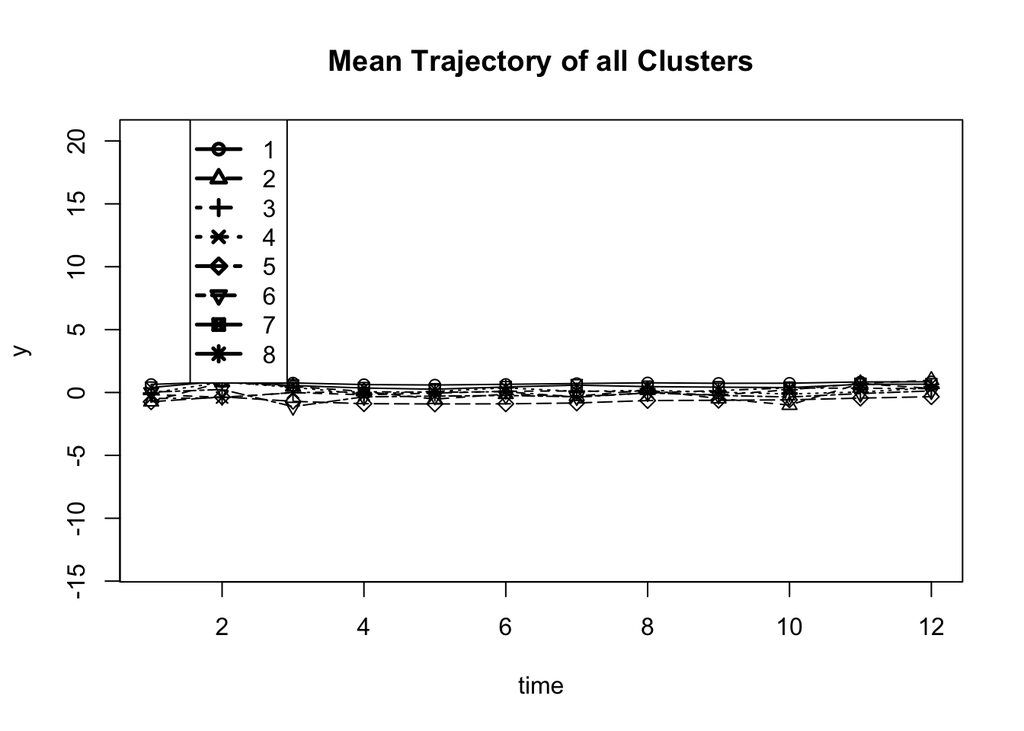

```r
plotCombTraj(s3.8clusters)
```